# Predicting Locational Marginal Electricity Prices in Goleta using Machine Learning

# Machine Learning Models Part 2

First, I create new training, testing, and folds datasets, as well as a new recipe using the limited list of predictors.

```r
# split all_model_data into training, testing sets
goleta_split_2 <- initial_split(all_model_data_2, prop = .8)
goleta_train_2 <- training(goleta_split_2)
goleta_test_2 <- testing(goleta_split_2)
# generate folds from training data
goleta_folds_2 <- vfold_cv(goleta_train_2, v = 3)
# generate recipe to predict LMP
goleta_recipe_2 <- recipe(lmp ~ ., data = goleta_train_2) %>%
  # center and scale predictors
  step_center(all_predictors()) %>%
  step_scale(all_predictors())
```

### Simple Linear Regression Part 2

A classical linear regression, with no perfectly correlated predictors, and all closely correlated predictors removed.

1 model

```r
goleta_lm_wflow_2 <- workflow() %>%
  add_model(goleta_lm_model) %>%
  add_recipe(goleta_recipe_2)

goleta_lm_fit_2 <- fit(goleta_lm_wflow_2, goleta_train_2)

goleta_train_res_2 <- predict(goleta_lm_fit_2, new_data = goleta_train_2 %>% select(-lmp))
goleta_train_res_2 <- bind_cols(goleta_train_res_2, goleta_train_2 %>% select(lmp))
goleta_lm_rmse_2 = rmse(goleta_train_res_2, truth = lmp, estimate = .pred)
goleta_lm_fs_2 = 1-goleta_lm_rmse_2$.estimate/goleta_persistence_rmse$.estimate
```

This new Simple Linear Regression has an RMSE of 13.4324791, giving it a forecasting skill of 0.1804464, outperforming the regularization model and nearly performing as well as the random forest (both using all model data)!

I’ll now test the performance of the Regularization, Random Forest, and Boosted Tree models on the limited dataset. Models should run much faster as there are less than half as many predictors, giving far fewer options for relationships between nodes.

### Regularization Model Part 2: tuning *penalty*, *mixture*

A regularized regression model finding the best values for penalty and mixture.

3 folds x 10 penalties x 6 mixtures = 180 models fit

```r
# build grid of tuning values
goleta_reg_grid_2 <- grid_regular(penalty(range = c(0, 4)), mixture(range = c(0, 0.5)), levels = c(penalty = 10, mixture = 6))
# set up workflow with tuning model
goleta_reg_wf_2 <- workflow() %>%
  add_model(goleta_reg_model) %>%
  add_recipe(goleta_recipe_2)
```

```
# tune models with folds, grid 5*10*6 = 300 models total
goleta_tune_regularization_2 <- tune_grid(
  goleta_reg_wf_2,
  resamples = goleta_folds_2,
  grid = goleta_reg_grid_2
)
# save goleta_tune_regularization
saveRDS(goleta_tune_regularization_2, file = here("outputs", "goleta_tune_regularization_2.rds"))
```

```r
goleta_tune_regularization_2 = readRDS(file = here("outputs", "goleta_tune_regularization_2.rds"))
```

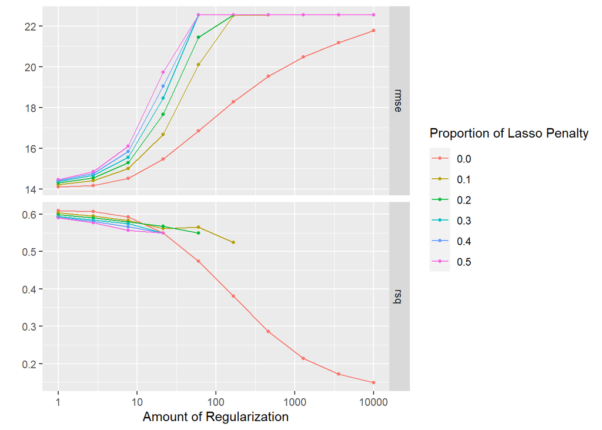

```r
# display model results
autoplot(goleta_tune_regularization_2)
```

```r
goleta_reg_metrics_2 = collect_metrics(goleta_tune_regularization_2) %>% filter(.metric == "rmse") %>% arrange(mean)

goleta_reg_best_rmse_2 = goleta_reg_metrics_2$mean[1]

goleta_reg_best_params_2 <- select_best(goleta_tune_regularization_2, metric = "rmse")
```

### Random Forest Part 2

```r
goleta_forest_wf_2 = workflow() %>%
  add_model(goleta_forest_model) %>%
  add_recipe(goleta_recipe_2)

goleta_param_grid_forest_2 <- grid_regular(mtry(range = c(50, 100)), trees(range = c(600,1000)), min_n(range = c(10,10)), levels = c(mtry = 1, trees = 1, min_n = 1))
```

```
goleta_tune_res_forest_2 <- tune_grid(
      goleta_forest_wf_2,
      resamples = goleta_folds_2,
      grid = goleta_param_grid_forest_2,
      metrics = metric_set(rmse)
    )

saveRDS(goleta_tune_res_forest_2, file = here("outputs", "goleta_tune_res_forest_2.rds"))
```

```r
goleta_tune_res_forest_2 = readRDS(file = here("outputs", "goleta_tune_res_forest_2.rds"))
```

```r
goleta_forest_metrics_2 = collect_metrics(goleta_tune_res_forest_2, metric = "rmse") %>% arrange(mean)

goleta_forest_best_rmse_2 = goleta_forest_metrics_2$mean[1]

goleta_forest_best_params_2 <- select_best(goleta_tune_res_forest_2, metric = "rmse")
```

```r
goleta_boost_wf_2 = workflow() %>%
  add_model(goleta_boost_model) %>%
  add_recipe(goleta_recipe_2)

goleta_param_grid_boost_2 <- grid_regular(trees(range = c(600, 600)), levels = 1)
```

```
goleta_tune_res_boost_2 <- tune_grid(
  goleta_boost_wf_2,
  resamples = goleta_folds_2,
  grid = goleta_param_grid_boost_2,
  metrics = metric_set(rmse)
)

saveRDS(goleta_tune_res_boost_2, file = here("outputs", "goleta_tune_res_boost_2.rds"))
```

```r
goleta_tune_res_boost_2 = readRDS(file = here("outputs", "goleta_tune_res_boost_2.rds"))
```

```r
goleta_boost_metrics_2 = collect_metrics(goleta_tune_res_boost_2) %>% arrange(mean)

goleta_boost_best_rmse_2 = goleta_boost_metrics_2$mean[1]

goleta_boost_best_params_2 <- select_best(goleta_tune_res_boost_2, metric = "rmse")
```

## RMSE and Forecasting Skill of Best Models

```r
disp_tbl_2 = matrix(nrow = 4, ncol = 2)
disp_tbl_2 = data.frame(disp_tbl_2)
colnames(disp_tbl_2) = c("Model", "RMSE")
disp_tbl_2[1:4, 1] = c("Simple Linear Regression", "Tuned Regularization", "Tuned Random Forest", "Tuned Boosted Tree")
disp_tbl_2[1:4, 2] = c(goleta_lm_rmse_2$.estimate, goleta_reg_best_rmse_2, goleta_forest_best_rmse_2, goleta_boost_best_rmse_2)

disp_tbl_2 = disp_tbl_2 %>%
  mutate(Metric = 1 - RMSE/goleta_persistence_rmse$.estimate)

disp_tbl_2
```

```
##                      Model     RMSE    Metric
## 1 Simple Linear Regression 13.43248 0.1804464
## 2     Tuned Regularization 14.10248 0.1395680
## 3      Tuned Random Forest 12.92088 0.2116607
## 4       Tuned Boosted Tree 12.61051 0.2305973
```

```r
saveRDS(disp_tbl_2, file = here("outputs", "disp_tbl_2.rds"))
```

```
disp_tbl_2 = readRDS(file = here("outputs", "disp_tbl_2.rds"))
disp_tbl_2
```

Table 3: RMSE and Forecasting Skill for Best Model of Each Type

### Fit Best Model to Training Data and Test Performance on Testing Data

The best model is now fit to the entire training dataset, and its performance tested on the testing data set, which it has not yet seen.

```r
best_model_2 = disp_tbl_2$Model[match(min(disp_tbl_2$RMSE), disp_tbl_2$RMSE)]
if (best_model_2 == "Tuned Regularization") {
  # finalize workflow and fit to training data
  goleta_final_wflow_2 <- finalize_workflow(goleta_reg_wf_2, goleta_reg_best_params_2)
} else if (best_model_2 == "Tuned Random Forest") {
  goleta_final_wflow_2 <- finalize_workflow(goleta_forest_wf_2, goleta_forest_best_params_2)
} else if (best_model_2 == "Tuned Boosted Tree") {
  goleta_final_wflow_2 <- finalize_workflow(goleta_boost_wf_2, goleta_boost_best_params_2)
} else {
  goleta_final_wflow_2 = goleta_lm_wflow_2
}
```

```
goleta_final_fit_2 <- fit(goleta_final_wflow_2, data = goleta_train_2)

saveRDS(goleta_final_fit_2, file = here("outputs", "goleta_final_fit_2.rds"))
```

```r
goleta_final_fit_2 = readRDS(file = here("outputs", "goleta_final_fit_2.rds"))
```

```r
  # calculate R2 of final fitted model on testing data
test_fit_2 = augment(goleta_final_fit_2, new_data = goleta_test_2)
test_rmse_2 = augment(goleta_final_fit_2, new_data = goleta_test_2) %>%
  rmse(truth = lmp, estimate = .pred)
test_metric_2 = 1-test_rmse_2$.estimate/goleta_test_persistence_rmse$.estimate
```

# Conclusion

## Model Performance

### Part 1: All Predictors

First, I’ll discuss the performance of the models fit to the entire data set. The persistence model, against which other models are being compared, had an RMSE of 16.3899947 on the training data and an RMSE of 15.47 on the testing data.

As expected, the simple linear regression failed completely, with an infinite error. This was due to the perfection correlation between predictors we discussed earlier.

The best regularization models had low penalties and were 100% ridge regression. This is as close as a regularized regression can get to simple linear regression, so I expect the simple linear regression with limited parameters to outperform this model. I expect that the regularization models would perform better if I was able to include all locations, as then a LASSO could be used for variable selection, and tree-based models would take too long to run and simple linear regression would not converge if p>n.

### Part 2: Only Non-Correlated Predictors

The best regularized model now performed worst than the simple linear regression, implying that imparting a penalty for variable inclusion is not necessary in this analysis. Again, the best model had the lowest penalty and was 100% ridge.

After eliminating perfectly correlated predictors, the simple linear regressions performed very well, with an RMSE of 13.4324791, a big step up from Infinite error! This regression had a forecassting skill of 0.1804464, and performed better than I expected a simple regression would on such complex data! To be fair, however, it took significant EDA and variable selection to get to this point.

The random forest improved after variable selection, with an RMSE of 12.9208763, nearly beating the best boosted tree with all predictors. I’m guessing this improvement is due to my being able to include more relationships and trees, without losing any valuable data in the closely correlated predictors.

### Best Models fit to Entire Training Data

The best models from Part 1 and Part 2 were then fit to the entire training and testing data sets. Interestingly, while the Part 2 Boosted Tree Model outperformed the Part 1 Boosted Tree Model (RMSE 12.6105062 vs 12.8225139) during cross validation, the Part 1 Boosted Tree (Using all predictors rather then the subset) performed better when trained on the entire training set and performance tested on the entire testing set. This could be due to the fact that I only cross-validated on k=3 folds, instead of the more typical k=5 or k=10. In future analyses I plan on switching to k=5 to hopefully remedy this issue.

It should be noted, however, that this current model is using *actual* weather data, when really we should be using day-ahead *forecasts*, as this is what the algorithm will have when working in real-time to predict LMPs. This will not impact the persistence RMSE, but will assuredly impact the model RMSEs, reducing the forecasting skill.

## Future Work

I plan on continuing with this analysis. My next steps are:

1. Switching to weather forecast instead of actual weather data
2. Cross-validating the *radius* parameter to determine an optimal radius. I excluded this from the current analyses as it will take some code restructuring to do this, as currently an entirely new dataset is pulled from BOX for a given radius.
3. Including all weather and location parameters in R for an initial LASSO. This will mean figuring out a work around for the space and memory issues I initially ran into.
4. After running the LASSO on all parameters, using the selected parameters within a boosted tree and random forest. I hope that the LASSO will select <100 parameters, so I can execute much larger numbers of Trees.
5. Expand the analysis to all nodes in California! Eventually my goal is to have a complete LMP forecaster for the state, that projects node prices 24 hours in advance.
6. Parameter interpretation, I hope that a LASSO on all location and weather parameters will yield causal insights into drivers of electricity price changes.
7. Inclusion and prediction of outliers, as I mentioned previously, sometimes prices spike and drop dramatically. Included these into the model will present a significant challenge, but may as well provide interesting insights.